# Drive Like a Girl

**Why we should look to women when it comes to stayin' alive on the roads**

[figure not shown]

*Photo by Jenny Ueberberg on Unsplash*

# Data Overview

In this analysis, we will be taking a look at [Australian road fatalities from 1989 to 2021](https://www.kaggle.com/datasets/deepcontractor/australian-fatal-car-accident-data-19892021). It includes road-related fatalities of drivers, passengers, pedestrians, motorcyclists and cyclists. There are around 52,000 records in the dataset.

You probably have some idea about what these statistics look like based on the various stories shared on mainstream media, but let's see if we can find anything interesting. So, hop in, put your seatbelt on, and let's go for a ride! :D

```python
# Install Google Colab module to enable file upload
!pip install google-colab
```

```python
# Import libraries
import numpy as np
import pandas as pd
from pandas.api.types import CategoricalDtype
import matplotlib.pyplot as plt
from matplotlib.patches import Rectangle
import seaborn as sns
from google.colab import files
import io
```

```python
# Upload Aus Fatal Road Accidents 1989-2021.csv
uploaded = files.upload()

df_crashes = pd.read_csv(io.StringIO(uploaded['Aus Fatal Road Accidents 1989-2021.csv'].decode('utf-8')))
```

```python
# Remove NaNs where NaN cannot be assumed to be any particular value
df_crashes = df_crashes[df_crashes['Time'].notna()]
df_crashes = df_crashes[df_crashes['Gender'].notna()]
df_crashes = df_crashes[df_crashes['Age Group'].notna()]

# Remove Ages below zero
df_crashes = df_crashes[df_crashes['Age'] >= 0]

# Remove vehicle operators aged zero
df_crashes = df_crashes.drop(df_crashes[(df_crashes['Road User'] == 'Driver') & (df_crashes['Age'] == 0)].index)
df_crashes = df_crashes.drop(df_crashes[(df_crashes['Road User'] == 'Motorcycle rider') & (df_crashes['Age'] == 0)].index)
df_crashes = df_crashes.drop(df_crashes[(df_crashes['Road User'] == 'Pedal cyclist') & (df_crashes['Age'] == 0)].index)

# Retain only the Hour in which the accident occurred
df_crashes['Time'] = df_crashes['Time'].apply(lambda x: str(x))
df_crashes['Hour'] = df_crashes['Time'].apply(lambda x: int(x.split(':')[0]))

# Remove Unspecified gender
df_crashes = df_crashes[df_crashes['Gender'] != 'Unspecified']

# Remove 'Other/-9' category in Road Users column
df_crashes = df_crashes[df_crashes['Road User'] != 'Other/-9']

# Remove underscores in Age Groups
df_crashes['Age Group'] = df_crashes['Age Group'].apply(lambda x: x.replace('_', ' '))

selected_cols = ['Year', 'Hour', 'Crash Type', 'Road User', 'Gender', 'Age', 'Age Group', 'Time of day']
df_crashes = df_crashes[selected_cols]
df_crashes = df_crashes.reset_index(drop=True)
```

```python
# Upload Aus Population 1989-2021.csv
uploaded = files.upload()

df_population = pd.read_csv(io.StringIO(uploaded['Aus Population 1989-2021.csv'].decode('utf-8')))
```

```python
# Reindex Population data
df_population.set_index(df_population['year'], drop=True, inplace=True)
df_population.drop('year', axis=1, inplace=True)
```

# Introduction

The World Heath Organisation reports that approximately 1.3 million lives are cut short across the globe each year as a result of road traffic accidents. It's no wonder Australia takes road safety so seriously. We often see [road safety ads](https://www.youtube.com/watch?v=nUPfD_FobwM) and hear about Level Crossing Removal projects on TV. And we're ahead of most of the world when it comes to [vehicle safety requirements](https://www.drive.com.au/news/autonomous-emergency-braking-will-be-compulsory-in-australia-from-2023/) and vehicle restrictions for inexperienced drivers. It seems like everything is being done to help reduce the danger on our roads, but how are we going when it comes to being safer drivers ourselves? Until fully autonomous cars become widely available, we remain in full control and take full responsibility for what happens when we drive.

# Where We're Going Wrong

Young adults are the most likely fatalities on our roads. From the age of 15, the deaths begin to increase rapidly, peaking at age 18, the age at which many people obtain a provisional driver's license and are granted extra freedoms by their parents. And the deaths remain quite high for people in their 20s, although it decreases as they age. The number of fatalities appears to plateau at around age 60.

While it's no secret that young people carry the most risk on our roads, this spike in deaths is still quite shocking when you visualise it. I'm sure most of us have done something silly when we were young. The only difference is that we got away with it.

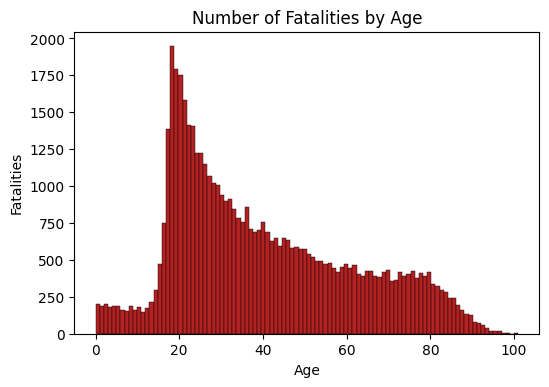

```python
# Fatalities by Age

ages = df_crashes['Age']

fig, ax = plt.subplots(figsize=(6, 4), dpi=100)
sns.histplot(ages, bins=ages.nunique(), color='firebrick', alpha=1)
ax.set_title('Number of Fatalities by Age')
ax.set_xlabel('Age')
ax.set_ylabel('Fatalities')

plt.show()
```

Let's take a closer look into where these fatalities are coming from.

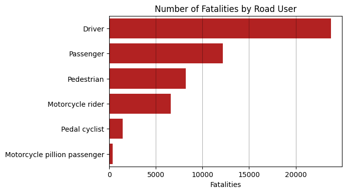

```python
# Fatalities by Road User

road_user_crashes = df_crashes['Road User'].value_counts()
road_user_crashes = road_user_crashes.sort_values(ascending=False)

fig, ax = plt.subplots(figsize=(6, 4), dpi=100)
sns.barplot(x=road_user_crashes, y=road_user_crashes.index, orient='h', color='firebrick', saturation=1)
ax.set_title('Number of Fatalities by Road User')
ax.set_xlabel('Fatalities')
plt.grid(color='k', axis='x', alpha=0.3)

plt.show()
```

```python
# Display Fatalities by Road User

road_user_crashes.name = ''
road_user_crashes.index.name = 'Road User'
display(pd.DataFrame(road_user_crashes))
```

| Road User |  |
| --- | --- |
| Driver | 23779 |
| Passenger | 12190 |
| Pedestrian | 8221 |
| Motorcycle rider | 6626 |
| Pedal cyclist | 1421 |
| Motorcycle pillion passenger | 361 |

Passenger deaths appear to spike with driver deaths. This may be caused by all the things people do when they get their license and their first car, such as driving their friends who don't yet have a license, or simply taking them for a spin in their new set of wheels. The rapid decline in passenger deaths as opposed to the slower decline of driver deaths could indicate that as they get older, many drivers were the sole occupant of their vehicle when the fatal accident occurred.

Pedestrians don't seem to be as lucky as the rest. The spike of deaths at young adulthood is accompanied by another spike in the late 70s. Perhaps it's worth taking the time to [help that old lady](https://www.youtube.com/watch?v=aIseeEUcOoU) cross the road.

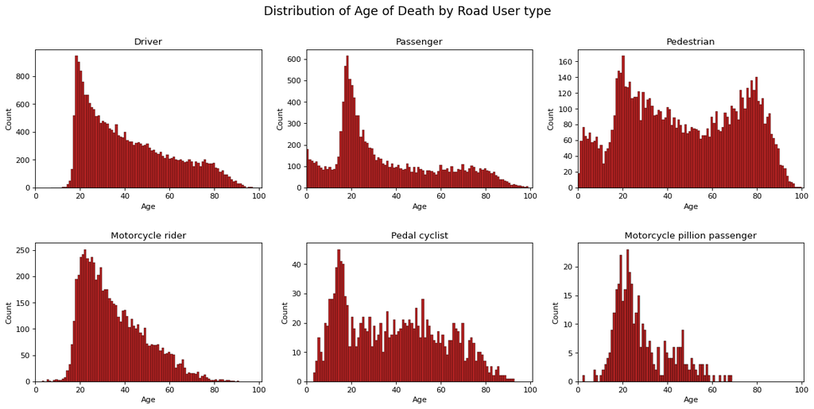

```python
# Distribution of Ages by Road User type

road_users = road_user_crashes.index
max_age = df_crashes['Age'].max()
min_age = df_crashes['Age'].min()
ages = {}

for i in road_users:
  ages[i] = df_crashes[df_crashes['Road User'] == i]['Age']

fig, ax = plt.subplots(nrows=2, ncols=3, figsize=(18,8), dpi=80)
fig.suptitle('Distribution of Age of Death by Road User type', fontsize=16)

i = 0
j = 0
for index in range(len(road_users)):
  bin_count = ages[road_users[index]].max() - ages[road_users[index]].min() + 1
  sns.histplot(ages[road_users[index]], bins=bin_count, color='firebrick', alpha=1, ax=ax[i][j])

  ax[i][j].set_title(road_users[index])
  ax[i][j].set_xlim([min_age, max_age])

  j += 1
  if j > 2:
    j = 0
    i += 1

plt.subplots_adjust(hspace=0.4)
plt.show()
```

# When We're Going Wrong

The deadlist time of day is mid to late afternoon. The number of fatalities is highest from 3:00pm to 4:00pm, which could be explained by the end of the school day. The afternoon peak from 4:00pm to 6:00pm also claims a lot of lives. People rushing home from work after a tiring day of work is likely to be one of the reasons why the afternoon is so much deadlier than the mornings. I'm sure you've experienced the Afternoon Slump before. Don't forget to bring some snacks to recharge!

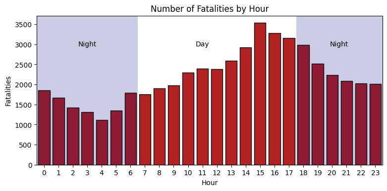

```python
# Fatalities by Hour

hourly_crashes = df_crashes['Hour'].value_counts()
hourly_crashes = hourly_crashes.sort_index(axis=0)

fig, ax = plt.subplots(figsize=(9, 4), dpi=100)
sns.barplot(x=hourly_crashes.index, y=hourly_crashes, color='firebrick', edgecolor='k', saturation=1)

ax.add_patch(Rectangle((-0.5, 0), 7, 4000, fill=True, alpha=0.2, color='navy', lw=0))
ax.add_patch(Rectangle((17.5, 0), 6, 4000, fill=True, alpha=0.2, color='navy', lw=0))
ax.annotate('Night', xy=(3, 3000), fontsize=10, color='black', va='center', ha='center')
ax.annotate('Day', xy=(11, 3000), fontsize=10, color='black', va='center', ha='center')
ax.annotate('Night', xy=(20.5, 3000), fontsize=10, color='black', va='center', ha='center')

ax.set_title('Number of Fatalities by Hour')
ax.set_xlabel('Hour')
ax.set_ylabel('Fatalities')
ax.set_xticks(hourly_crashes.index)

plt.show()
```

It's surprising to see how the number of deaths in the early morning compares with those in the middle of the day. Despite the roads being virtually empty at 4:00am, the number of deaths recorded at that time are still around half of that at midday.

Pedestrians and cyclists are most at risk during the morning and afternoon rush hours. The fatalities of all other road users experience a sharp peak in the middle of the afternoon, except for drivers whose fatalties are more evenly spread out. Their relatively higher death rate in the early hours is likely to be the reason why the overall deaths during those times are disproportionately higher.

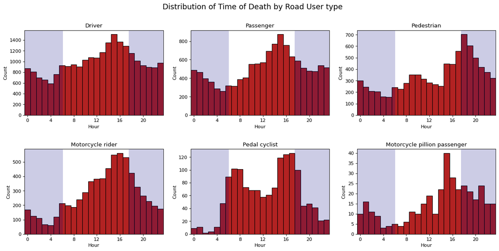

```python
# Time of accident by Road User type

road_users = road_user_crashes.index
hours = {}

for i in road_users:
  hours[i] = df_crashes[df_crashes['Road User'] == i]['Hour']

fig, ax = plt.subplots(nrows=2, ncols=3, figsize=(18,8), dpi=80)
fig.suptitle('Distribution of Time of Death by Road User type', fontsize=16)

i = 0
j = 0
for index in range(len(road_users)):
  sns.histplot(hours[road_users[index]], bins=np.arange(25)-0.5, color='firebrick', alpha=1, ax=ax[i][j])
  max_height = ax[i][j].get_ylim()[1]
  ax[i][j].set_title(road_users[index])
  ax[i][j].add_patch(Rectangle((0, 0), 0, max_height, fill=True, alpha=0, color='white', lw=0))
  ax[i][j].add_patch(Rectangle((-0.5, 0), 6.6, max_height, fill=True, color='navy', alpha=0.2, lw=0))
  ax[i][j].add_patch(Rectangle((17.5, 0), 6, max_height, fill=True, color='navy', alpha=0.2, lw=0))
  ax[i][j].set_xticks(np.arange(0, 23, 4))
  ax[i][j].margins(x=0, y=0)

  j += 1
  if j > 2:
    j = 0
    i += 1

plt.subplots_adjust(hspace=0.4)
plt.show()
```

While more drivers are killed during the day time, the majority of those accidents involved multiple vehicles. Single vehicle accidents are around twice as common than multiple vehicle accidents during the darker hours of the day (7:00pm to 5:00am).

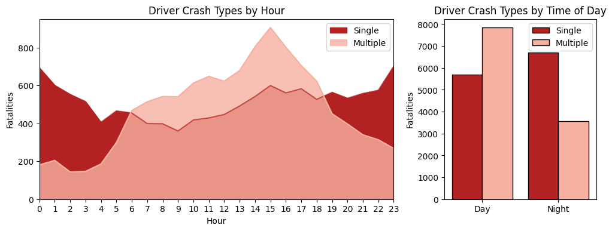

```python
# Single and Multiple vehicle fatalities by Hour

drivers = df_crashes[df_crashes['Road User'] == 'Driver']
drivers = drivers.sort_values(['Time of day'])
single_crashes = drivers[drivers['Crash Type'] == 'Single']['Hour'].value_counts().sort_index(axis=0)
multi_crashes = drivers[drivers['Crash Type'] == 'Multiple']['Hour'].value_counts().sort_index(axis=0)

fig, ax = plt.subplots(nrows=1, ncols=2, figsize=(12, 4), dpi=100, gridspec_kw={'width_ratios': [7, 3]})
sns.lineplot(x=single_crashes.index, y=single_crashes, color='firebrick', alpha=0.7, ax=ax[0])
ax[0].fill_between(single_crashes.index, 0, single_crashes, color='firebrick', alpha=1, label='Single')
sns.lineplot(x=multi_crashes.index, y=multi_crashes, color='#F7B1A1', alpha=1, ax=ax[0])
ax[0].fill_between(multi_crashes.index, 0, multi_crashes, color='#F7B1A1', alpha=0.8, label='Multiple')

ax[0].add_patch(Rectangle((0, 0), 0, ax[0].get_ylim()[1], fill=True, alpha=0, color='white', lw=0))

ax[0].set_title('Driver Crash Types by Hour')
ax[0].set_xlabel('Hour')
ax[0].set_ylabel('Fatalities')
ax[0].set_xticks(range(24))
ax[0].legend()
ax[0].margins(x=0, y=0)

sns.countplot(data=drivers, x='Time of day', hue='Crash Type', hue_order=['Single', 'Multiple'], edgecolor='k', palette=['firebrick', '#F7B1A1'], saturation=1, ax=ax[1])
ax[1].set_title('Driver Crash Types by Time of Day')
ax[1].set_xlabel('')
ax[1].set_ylabel('Fatalities')
ax[1].legend(loc='upper right')

plt.show()
```

# Who's The Most Dangerous?

Multiple vehicle accidents can cause the death of drivers who were doing the right thing. Sometimes, you don't expect someone to speed through a red light and T-bone you or drift onto your side of the road on a dark night in the country.

In contrast, single vehicle accidents are almost always a result of driver fault and is therefore a better indicator of who the safer drivers are.

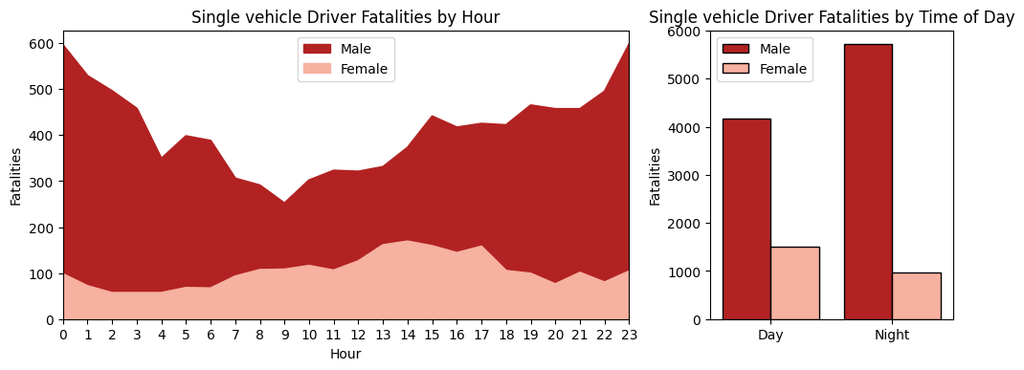

```python
# Single vehicle fatalities of Male and Female Drivers by Hour

single_drivers = df_crashes[(df_crashes['Road User'] == 'Driver') & (df_crashes['Crash Type'] == 'Single')]
single_drivers = single_drivers.sort_values(['Gender'], ascending=False)
male_crashes = single_drivers[single_drivers['Gender'] == 'Male']['Hour'].value_counts().sort_index(axis=0)
female_crashes = single_drivers[single_drivers['Gender'] == 'Female']['Hour'].value_counts().sort_index(axis=0)

fig, ax = plt.subplots(nrows=1, ncols=2, figsize=(12, 4), dpi=100, gridspec_kw={'width_ratios': [7, 3]})
sns.lineplot(x=male_crashes.index, y=male_crashes, color='firebrick', alpha=1, ax=ax[0])
ax[0].fill_between(male_crashes.index, 0, male_crashes, color='firebrick', alpha=1, label='Male')
sns.lineplot(x=female_crashes.index, y=female_crashes, color='#F7B1A1', alpha=1, ax=ax[0])
ax[0].fill_between(female_crashes.index, 0, female_crashes, color='#F7B1A1', alpha=1, label='Female')

ax[0].add_patch(Rectangle((0, 0), 0, ax[0].get_ylim()[1], fill=True, alpha=0, color='white', lw=0))

ax[0].set_title('Single vehicle Driver Fatalities by Hour')
ax[0].set_xlabel('Hour')
ax[0].set_ylabel('Fatalities')
ax[0].set_xticks(range(24))
ax[0].legend(loc='upper center')
ax[0].margins(x=0, y=0)

sns.countplot(data=single_drivers, x='Time of day', order=['Day', 'Night'], hue='Gender', edgecolor='k', palette=['firebrick', '#F7B1A1'], saturation=1, ax=ax[1])
ax[1].set_title('Single vehicle Driver Fatalities by Time of Day')
ax[1].set_xlabel('')
ax[1].set_ylabel('Fatalities')
ax[1].legend(loc='upper left')

plt.show()
```

```python
# Display Male and Female Single vehicle Driver fatalities by Time of Day

single_drivers_tod = single_drivers.groupby('Time of day')['Gender'].value_counts()
single_drivers_tod.name = ''
display(pd.DataFrame(single_drivers_tod))
```

| Time of day | Gender |  |
| --- | --- | --- |
| Day | Male | 4170 |
|  | Female | 1514 |
| Night | Male | 5720 |
|  | Female | 974 |

Males are the more dangerous drivers by far. They make up 73% of day time fatalities and a whopping 85% of night time fatalities!

The interesting thing is that male and female drivers experience the most fatalities at different times of the day. Male deaths peak around midnight while female deaths peak around lunch time.

Recording higher deaths in the middle of the day isn't so surprising since more people drive during that time. So something must be happening in the middle of the night for so many men to lose their lives behind the wheel. Street racing, dingoes, aliens? Who knows?

It's not looking good for men involved in multiple vehicle accidents either. They record over double the number of fatalities in that category compared to women.

But while female fatalities in single and multiple vehicle accidents are practically even, around 33% more males are killed in single vehicle accidents compared to multiple vehicle accidents.

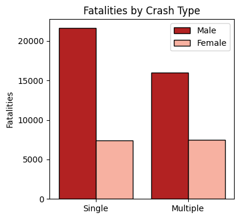

```python
# Male and Female fatalities by Crash Type

fig, ax = plt.subplots(figsize=(4, 4), dpi=100)
sns.countplot(data=df_crashes, x='Crash Type', hue='Gender', hue_order=['Male', 'Female'], order=['Single', 'Multiple'], edgecolor='k', palette=['firebrick', '#F7B1A1'], saturation=1)

ax.set_title('Fatalities by Crash Type')
ax.set_xlabel('')
ax.set_ylabel('Fatalities')
ax.legend(loc='upper right')

plt.show()
```

The distribution of multiple vehicle fatalities between males and females looks quite similar with deaths peaking in the middle of the afternoon and decline towards the end of the day. Men record twice as many multiple vehicle deaths as women during the day, but the difference is even larger during the night.

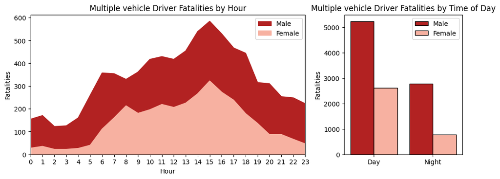

```python
# Multiple vehicle fatalities of Male and Female Drivers by Hour

multi_drivers = df_crashes[(df_crashes['Road User'] == 'Driver') & (df_crashes['Crash Type'] == 'Multiple')]
male_crashes = multi_drivers[multi_drivers['Gender'] == 'Male']['Hour'].value_counts().sort_index(axis=0)
female_crashes = multi_drivers[multi_drivers['Gender'] == 'Female']['Hour'].value_counts().sort_index(axis=0)

fig, ax = plt.subplots(nrows=1, ncols=2, figsize=(12, 4), dpi=100, gridspec_kw={'width_ratios': [7, 3]})
sns.lineplot(x=male_crashes.index, y=male_crashes, color='firebrick', alpha=1, ax=ax[0])
ax[0].fill_between(male_crashes.index, 0, male_crashes, color='firebrick', alpha=1, label='Male')
sns.lineplot(x=female_crashes.index, y=female_crashes, color='#F7B1A1', alpha=1, ax=ax[0])
ax[0].fill_between(female_crashes.index, 0, female_crashes, color='#F7B1A1', alpha=1, label='Female')

ax[0].add_patch(Rectangle((0, 0), 0, ax[0].get_ylim()[1], fill=True, alpha=0, color='white', lw=0))

ax[0].set_title('Multiple vehicle Driver Fatalities by Hour')
ax[0].set_xlabel('Hour')
ax[0].set_ylabel('Fatalities')
ax[0].set_xticks(range(24))
ax[0].legend(loc='upper right')
ax[0].margins(x=0, y=0)

sns.countplot(data=multi_drivers, x='Time of day', order=['Day', 'Night'], hue='Gender', edgecolor='k', palette=['firebrick', '#F7B1A1'], saturation=1, ax=ax[1])
ax[1].set_title('Multiple vehicle Driver Fatalities by Time of Day')
ax[1].set_xlabel('')
ax[1].set_ylabel('Fatalities')
ax[1].legend(loc='upper right')

plt.show()
```

```python
# Display Male and Female Multiple vehicle Driver fatalities by Time of Day

multi_drivers_tod = multi_drivers.groupby('Time of day')['Gender'].value_counts()
multi_drivers_tod.name = ''
display(pd.DataFrame(multi_drivers_tod))
```

| Time of day | Gender |  |
| --- | --- | --- |
| Day | Male | 5237 |
|  | Female | 2609 |
| Night | Male | 2782 |
|  | Female | 773 |

## What Makes Them Dangerous?

The difference in deaths between male and female drivers is a lot closer in multiple vehicle accidents than single vehicle accidents, but males are still more dangerous.

Apart from hooning and doing stunts at night, male driving behaviour is more dangerous in general. A report by the Insurance Institute for Highway Safety (IIHS) shows that males regularly engage in more risky driving practices such as not wearing a seatbelt, driving under the influence of alcohol and speeding. Crashes involving male drivers were often more severe than those involving females.

Men were also found to be more aggressive drivers. Behaviour such as tailgaiting, changing lanes dangerously and displaying aggressive and rude behaviour to other road users was more common in males than females. Additionally, younger drivers were found to be more aggressive than older drivers in general.

Men were also found to be 3.4 times more likely than women to be ticketed for reckless driving, according to a study conducted by research firm Quality Planning.

It's no wonder why car insurance costs more for men.

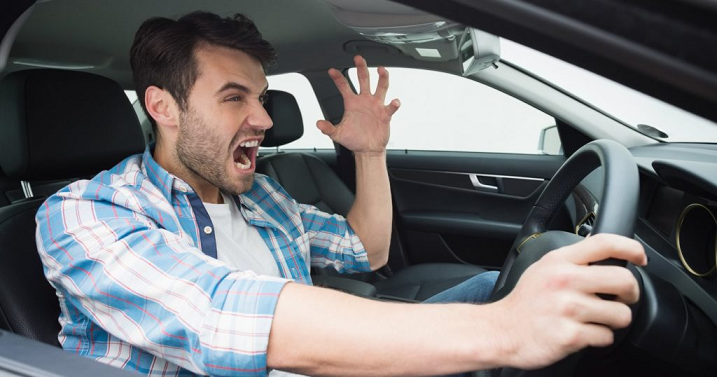

*Photo from Eclipse Driving School*

So what makes a driver safe? Let's take a quick look at the behavioural differences in males and females.

If we go back thousands and thousands of years, qualities that enabled males to survive involved aggressive behaviour and risk-taking. Females on the other hand did not require these qualities. They were more concerned about caring for and protecting people around them - their children in particular.

Here are some key behavioural traits for males and females

| **Males** | **Females** |
| --- | --- |
| Dominant | Sociable |
| Assertive | Sensitive |
| Risk-prone | Warm |
| Thrill-seeking | Compassionate |
| Tough-minded | Polite |
| Emotionally stable | Anxious |
| Utilitarian | Self-doubting |

These qualities are reflected in driving behaviour, and unfortunately it makes men more dangerous behind the wheel.

Evolutionary behaviour isn't something that's easy to control. It's not easy to change something that's been programmed into us, but if we know what we need to do and we're more conscious about our actions, that can certainly help.

So guys, do us all a favour and drive like a girl!

Jake Nelson, the director of the AAA Foundation for Traffic Safety agrees:  
"*Driving aggressively isn’t worth the risk. When you get behind the wheel, be patient, be kind, and obey traffic laws so everyone gets home safely.*"

# It's Not All Bad

Despite all that, we're actually doing very well when it comes to stayin' alive!

The mortality rate has been decreasing fairly consistently since 1989. We've gone down from 16 deaths per 100,000 to just three! With safer cars and more safety measures being put into place, we should only expect this to decline even more.

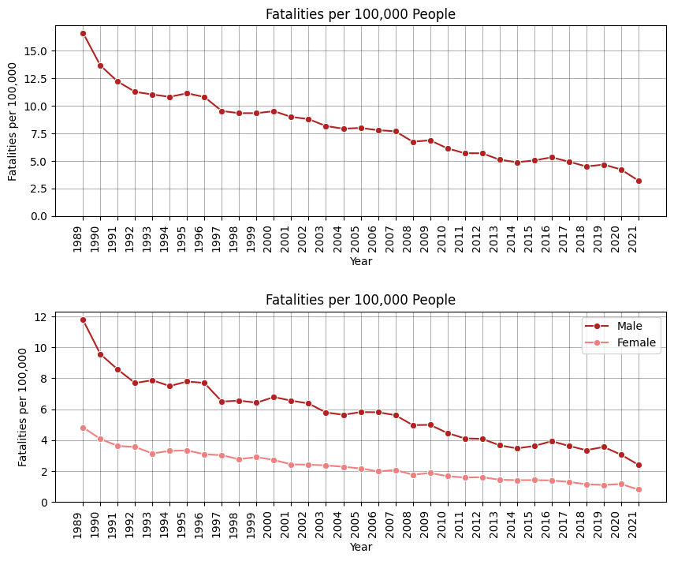

```python
# Deaths per 100,000 people by Year

total_deaths = df_crashes['Year'].value_counts()
male_deaths = df_crashes[df_crashes['Gender'] == 'Male']['Year'].value_counts()
female_deaths = df_crashes[df_crashes['Gender'] == 'Female']['Year'].value_counts()
total_deaths = total_deaths.sort_index()
male_deaths = male_deaths.sort_index()
female_deaths = female_deaths.sort_index()

# Calculate deaths per 100,000 people
x = 100000/df_population['population']
total_deaths = total_deaths*x
male_deaths = male_deaths*x
female_deaths = female_deaths*x

fig, ax = plt.subplots(nrows=2, ncols=1, figsize=(10, 8), dpi=100)
sns.lineplot(x=total_deaths.index, y=total_deaths, color='firebrick', alpha=1, marker='o', ax=ax[0])
ax[0].set_title('Fatalities per 100,000 People')
ax[0].set_xticks(total_deaths.index)
ax[0].set_xlabel('Year')
ax[0].set_ylabel('Fatalities per 100,000')
ax[0].set_ylim(ymin=0)
plt.draw()
ax[0].set_xticklabels(ax[0].get_xticklabels(), rotation=90, ha='right')

sns.lineplot(x=male_deaths.index, y=male_deaths, color='firebrick', alpha=1, marker='o', label='Male', ax=ax[1])
sns.lineplot(x=female_deaths.index, y=female_deaths, color='lightcoral', alpha=1, marker='o', label='Female', ax=ax[1])
ax[1].set_title('Fatalities per 100,000 People')
ax[1].set_xticks(male_deaths.index)
ax[1].set_xlabel('Year')
ax[1].set_ylabel('Fatalities per 100,000')
ax[1].set_ylim(ymin=0)
ax[1].legend(loc='upper right')
plt.draw()
ax[1].set_xticklabels(ax[1].get_xticklabels(), rotation=90, ha='right')

ax[0].grid(color='k', axis='x', alpha=0.3)
ax[0].grid(color='k', axis='y', alpha=0.3)
ax[1].grid(color='k', axis='x', alpha=0.3)
ax[1].grid(color='k', axis='y', alpha=0.3)

plt.subplots_adjust(hspace=0.5)
plt.show()
```

A big improvement can also be seen from our younger road users. The mortality rate of people aged 0 to 39 has decreased much more than those aged 40+. Given that the majority of road fatalities are younger people, this is great news!

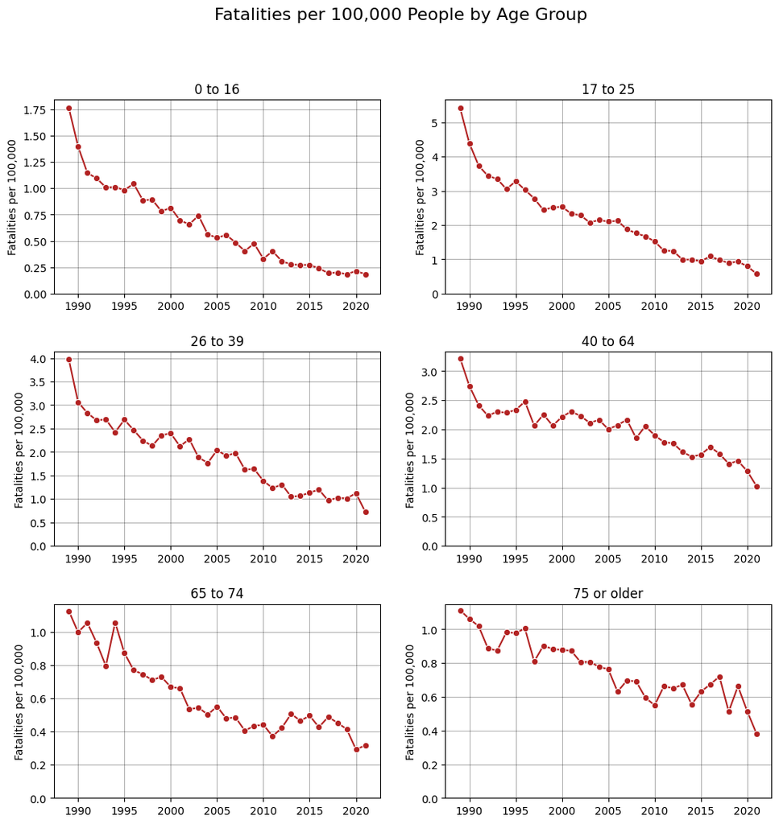

```python
# Deaths per 100,000 people by Year

total_deaths = df_crashes['Year'].value_counts()
total_deaths = total_deaths.sort_index()

age_groups = df_crashes['Age Group'].unique()
age_groups.sort()
years = {}

for i in age_groups:
  years[i] = df_crashes[df_crashes['Age Group'] == i]['Year'].value_counts().sort_index()
  years[i] = years[i]*x

# Calculate deaths per 100,000 people
x = 100000/df_population['population']
total_deaths = total_deaths*x
male_deaths = male_deaths*x
female_deaths = female_deaths*x

fig, ax = plt.subplots(nrows=3, ncols=2, figsize=(12, 12), dpi=100)
fig.suptitle('Fatalities per 100,000 People by Age Group', fontsize=16)

i = 0
j = 0
for group in age_groups:
  sns.lineplot(x=years[group].index, y=years[group], color='firebrick', alpha=1, marker='o', ax=ax[i][j])
  ax[i][j].set_title(group)
  ax[i][j].set_ylabel('Fatalities per 100,000')
  ax[i][j].set_ylim(ymin=0)

  ax[i][j].grid(color='k', axis='x', alpha=0.3)
  ax[i][j].grid(color='k', axis='y', alpha=0.3)

  j += 1
  if j > 1:
    j = 0
    i += 1

plt.subplots_adjust(hspace=0.3)
plt.show()
```

# Conclusion

In the past 33 years, we have lost 52,000 lives on Australian roads. Drivers are our most common fatalities with young, inexperienced drivers in early adulthood being the riskiest by far. Fortunately, as people grow older and gain more experience, the number of driver deaths declines, but the same can't be said for pedestrians whose deaths begin to increase again at around age 60. **So it's important for us to look out for our older road users.**

We also need to take a different approach to driving depending on the time of day. The morning and afternoon rush hours are the most dangerous for cyclists, and the afternoons are particularly dangerous for drivers and pedestrians. We've seen that the majority of driver deaths during the day are caused by multiple-vehicle accidents while an even greater majority of driver deaths at night are a result of single-vehicle accidents. **During the day, drivers should look out for other road users. During the night, they should look out for themselves.**

Additionally, we have seen a significantly higher number of male fatalities compared to female fatalities. Men are found to be hard-wired differently to women, which results in more aggressive and risky driving behaviour, leading to a greater chance of having an accident. This makes women the safer drivers, so **it wouldn't hurt for everyone to drive like a girl.**

# Sources

- https://www.savvy.com.au/who-are-better-drivers-men-or-women
- https://www.edriving.com/three60/aaa-research-reveals-men-have-more-dangerous-driving-habits/
- https://www.forbes.com/sites/tanyamohn/2020/12/13/men-are-more-aggressive-drivers-but-when-it-comes-to-speeding-women-are-not-far-behind
- https://www.cbsnews.com/news/men-vs-women-who-are-safer-drivers
- https://www.who.int/news-room/fact-sheets/detail/road-traffic-injuries
- https://www.greenslips.com.au/blog/women-are-safer-drivers.html
- https://www.greenslips.com.au/blog/middle-aged-men-are-dying-on-the-roads.html
- https://blogs.scientificamerican.com/beautiful-minds/taking-sex-differences-in-personality-seriously/